# Module 1: Single Instrument Pricing

## 12. Effective Duration & Convexity

The analytical Modified Duration and Convexity formulas assume cash flows are **static** — they don't change when interest rates move. For plain vanilla bonds this is correct. For bonds with **embedded options** (callable/puttable bonds), expected cash flows *do* change when rates move, so we need a numerical approach.

**Effective Duration** and **Effective Convexity** reprice the bond after shifting the entire yield curve by a small amount (the standard bump is 1 bp) and use central-difference formulas:

$$ \text{EffD} = \frac{P_{\downarrow} - P_{\uparrow}}{2 \cdot \Delta y \cdot P_0} \qquad \text{EffCx} = \frac{P_{\uparrow} - 2P_0 + P_{\downarrow}}{(\Delta y)^2 \cdot P_0} $$

For plain vanilla bonds these should converge to the analytical ModD / Cx as the bump size shrinks.

```python
from src.risk.convexity import convexity
from src.risk.duration import modified_duration
from src.risk.effective import effective_convexity, effective_duration

b = Bond(100, 0.05, 5.0, 2)
y = 0.05

modd = modified_duration(b, y)
effd = effective_duration(b, y)
cx = convexity(b, y)
effcx = effective_convexity(b, y)

print("Bond: 5yr, 5% semi-annual @ y = 5%")
print(f"  Modified Duration:     {modd:.8f}")
print(f"  Effective Duration:     {effd:.8f}")
print(f"  Δ = {abs(modd - effd):.2e}  |  Match: {abs(modd - effd) < 1e-4}\n")
print(f"  Convexity (analytical): {cx:.8f}")
print(f"  Effective Convexity:    {effcx:.8f}")
print(f"  Δ = {abs(cx - effcx):.2e}  |  Match: {abs(cx - effcx) < 1e-2}")
```

```
Bond: 5yr, 5% semi-annual @ y = 5%
  Modified Duration:     4.37603197
  Effective Duration:     4.37603218
  Δ = 2.16e-07  |  Match: True

  Convexity (analytical): 22.61232219
  Effective Convexity:    22.61232265
  Δ = 4.67e-07  |  Match: True
```

### Negative Convexity — Callable Bond Toy Model

A callable bond gives the issuer the right to redeem the bond before maturity. When rates fall far enough that it becomes economical to refinance, the bond's price is **capped** at the call price — the upside is truncated. This introduces **negative convexity**: duration decreases as yields fall, reversing the normal vanilla-bond behaviour.

Here we simulate this by comparing two price-yield curves: one for a plain vanilla 10yr bond, and one where the price is artificially capped at 102 (mimicking a call provision).

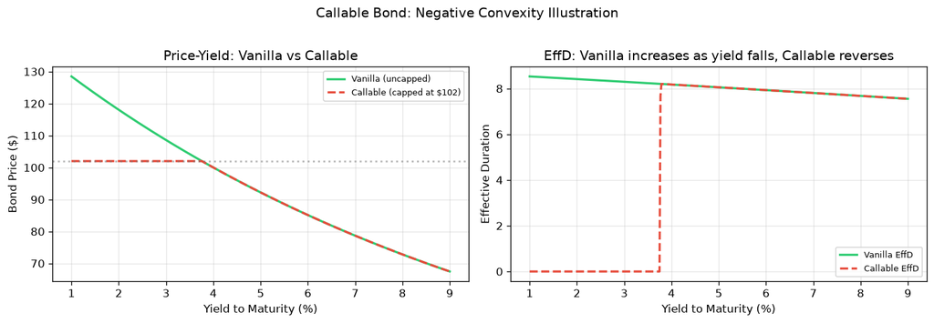

```python
b10 = Bond(100, 0.04, 10.0, 2)
y_range = np.linspace(0.01, 0.09, 400)

prices_vanilla = np.array([price(b10, y) for y in y_range])
call_price = 102.0
prices_callable = np.minimum(prices_vanilla, call_price)

# Effective duration at each yield level
effd_vanilla = np.array([effective_duration(b10, y) for y in y_range])

# For callable, approx effective duration via finite diff on capped prices
dy = 1e-4
effd_callable = np.array(
    [
        (min(price(b10, y - dy), call_price) - min(price(b10, y + dy), call_price))
        / (2 * dy * min(price(b10, y), call_price))
        for y in y_range
    ]
)

fig, (ax1, ax2) = subplots(nrows=1, ncols=2, figsize=(12, 4))

ax1.plot(
    y_range * 100,
    prices_vanilla,
    "-",
    color="#2ecc71",
    linewidth=2,
    label="Vanilla (uncapped)",
)
ax1.plot(
    y_range * 100,
    prices_callable,
    "--",
    color="#e74c3c",
    linewidth=2,
    label="Callable (capped at $102)",
)
ax1.axhline(call_price, color="gray", ls=":", alpha=0.5)
ax1.set_xlabel("Yield to Maturity (%)")
ax1.set_ylabel("Bond Price ($)")
ax1.set_title("Price-Yield: Vanilla vs Callable")
ax1.legend(fontsize=8)
finish_plot(ax1, grid=True, legend=False)

ax2.plot(
    y_range * 100, effd_vanilla, "-", color="#2ecc71", linewidth=2, label="Vanilla EffD"
)
ax2.plot(
    y_range * 100,
    effd_callable,
    "--",
    color="#e74c3c",
    linewidth=2,
    label="Callable EffD",
)
ax2.set_xlabel("Yield to Maturity (%)")
ax2.set_ylabel("Effective Duration")
ax2.set_title("EffD: Vanilla increases as yield falls, Callable reverses")
ax2.legend(fontsize=8)
finish_plot(ax2, grid=True, legend=False)

plt.suptitle("Callable Bond: Negative Convexity Illustration", fontsize=12, y=1.02)
plt.tight_layout()
plt.show()
```

## 13. Regulatory Stress Scenarios (Basel IRBB)

| # | Scenario | Description |
| --- | --- | --- |
| 1 | **Parallel Up** | +100 bp shift at all tenors |
| 2 | **Parallel Down** | −100 bp shift at all tenors |
| 3 | **Steepener** | Short rates −100 bp → Long rates +100 bp |
| 4 | **Flattener** | Short rates +100 bp → Long rates −100 bp |
| 5 | **Short Rate Up** | Short end +300 bp, decaying to 0 at 20yr |
| 6 | **Short Rate Down** | Short end −300 bp, decaying to 0 at 20yr |

The key insight: non-parallel scenarios affect different bonds differently. A **barbell** portfolio (short + long) has very different steepener/flattener exposure compared to a **bullet** portfolio (intermediate maturity).

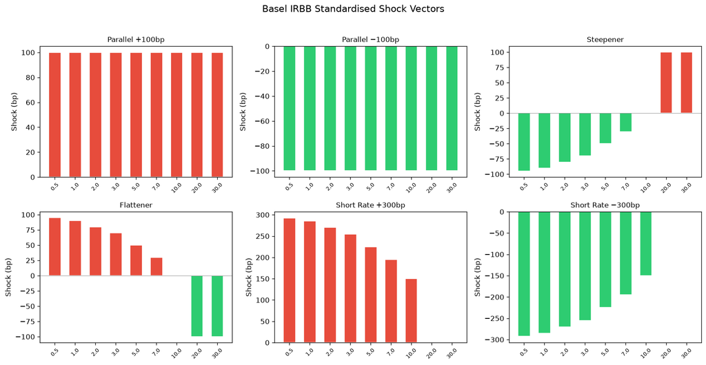

```python
from src.risk.shock import shocked_price
from src.risk.stress import irbb_shock_vector, irbb_stress_scenarios

# Visualize the six shock vectors at standard key-rate tenors
standard_tenors = [0.5, 1.0, 2.0, 3.0, 5.0, 7.0, 10.0, 20.0, 30.0]
scenario_names = [
    "parallel_up",
    "parallel_down",
    "steepener",
    "flattener",
    "short_rate_up",
    "short_rate_down",
]
labels = [
    "Parallel +100bp",
    "Parallel −100bp",
    "Steepener",
    "Flattener",
    "Short Rate +300bp",
    "Short Rate −300bp",
]

fig, axes = subplots(nrows=2, ncols=3, figsize=(14, 7))
axes_flat = axes.flatten()

for ax, name, label in zip(axes_flat, scenario_names, labels):
    shocks = irbb_shock_vector(name, standard_tenors)
    colors = ["#e74c3c" if s > 0 else "#2ecc71" for s in shocks]
    ax.bar(
        [str(t) for t in standard_tenors],
        [s * 10000 for s in shocks],
        color=colors,
        edgecolor="white",
        width=0.6,
    )
    ax.axhline(0, color="gray", lw=0.5)
    ax.set_title(label, fontsize=10)
    ax.set_ylabel("Shock (bp)")
    ax.tick_params(axis="x", rotation=45, labelsize=8)

fig.suptitle("Basel IRBB Standardised Shock Vectors", fontsize=13, y=1.02)
plt.tight_layout()
plt.show()
```

```python
# Apply IRBB scenarios to bonds of different maturities
test_bonds_irbb = [
    (Bond(100, 0.05, 2.0, 2), "2yr bullet"),
    (Bond(100, 0.05, 10.0, 2), "10yr bullet"),
]
y_irbb = 0.05

for bond, label in test_bonds_irbb:
    results = irbb_stress_scenarios(bond, y_irbb)
    p0 = price(bond, y_irbb)
    print(f"{label} (P = ${p0:.2f}, y = {y_irbb * 100:.0f}%)")
    print(f"  {'Scenario':<20} {'Price':>10} {'P&L':>10} {'P&L %':>8}")
    print(f"  {'-' * 48}")
    for name, data in results.items():
        pnl_pct = data["pnl"] / p0 * 100
        print(
            f"  {name:<20} {data['price']:>10.4f} {data['pnl']:>+10.4f} {pnl_pct:>+7.2f}%"
        )
    print()

# Barbell vs bullet comparison
short_bond = Bond(100, 0.03, 2.0, 2)
long_bond = Bond(100, 0.06, 10.0, 2)
barbell_qty = [50, 50]  # 50 units each
bullet = Bond(100, 0.05, 5.0, 2)
y_s, y_l, y_b = 0.04, 0.06, 0.05

# Portfolio-level stress
p0_short = price(short_bond, y_s)
p0_long = price(long_bond, y_l)
port_mv = barbell_qty[0] * p0_short + barbell_qty[1] * p0_long

short_res = irbb_stress_scenarios(short_bond, y_s)
long_res = irbb_stress_scenarios(long_bond, y_l)
bullet_res = irbb_stress_scenarios(bullet, y_b)
p0_bullet = price(bullet, y_b)

print(f"{'Scenario':<20} {'Barbell P&L%':>12} {'Bullet P&L%':>12} {'Diff':>8}")
print(f"  {'-' * 50}")
for name in short_res:
    barbell_pnl = (
        barbell_qty[0] * short_res[name]["pnl"] + barbell_qty[1] * long_res[name]["pnl"]
    )
    barbell_pnl_pct = barbell_pnl / port_mv * 100
    bullet_pnl_pct = bullet_res[name]["pnl"] / p0_bullet * 100
    diff = barbell_pnl_pct - bullet_pnl_pct
    print(
        f"  {name:<20} {barbell_pnl_pct:>+11.2f}% {bullet_pnl_pct:>+11.2f}% {diff:>+7.2f}%"
    )
```

```
2yr bullet (P = $100.00, y = 5%)
  Scenario                  Price        P&L    P&L %
  ------------------------------------------------
  parallel_up             98.1415    -1.8585   -1.86%
  parallel_down          101.9039    +1.9039   +1.90%
  steepener              101.5253    +1.5253   +1.53%
  flattener               98.5039    -1.4961   -1.50%
  short_rate_up           95.0739    -4.9261   -4.93%
  short_rate_down        105.2573    +5.2573   +5.26%

10yr bullet (P = $100.00, y = 5%)
  Scenario                  Price        P&L    P&L %
  ------------------------------------------------
  parallel_up             92.5613    -7.4387   -7.44%
  parallel_down          108.1757    +8.1757   +8.18%
  steepener              100.6445    +0.6445   +0.64%
  flattener               99.3696    -0.6304   -0.63%
  short_rate_up           88.2239   -11.7761  -11.78%
  short_rate_down        113.6154   +13.6154  +13.62%

Scenario             Barbell P&L%  Bullet P&L%     Diff
  --------------------------------------------------
  parallel_up                -4.53%       -4.27%   -0.26%
  parallel_down              +4.90%       +4.49%   +0.40%
  steepener                  +1.14%       +2.31%   -1.17%
  flattener                  -1.12%       -2.25%   +1.13%
  short_rate_up              -8.25%       -9.42%   +1.17%
  short_rate_down            +9.30%      +10.59%   -1.29%
```

## Summary

[output not shown]

# Module 3: Discrete Term Structure (Bootstrapping)

Extracting zero-coupon spot rates from a par yield curve using recursive bootstrapping. We verify against textbook examples and compare annual vs. semi-annual handling.

```python
# ruff: noqa: E402
import sys
import warnings

sys.path.insert(0, "..")
warnings.filterwarnings("ignore")

import numpy as np
import pandas as pd

from src.bootstrap.bootstrap import bootstrap_spot_rates
from src.instruments.bond import Bond
from src.utils.plotting import figure, finish_plot, set_theme

set_theme()
print("All imports OK")
```

```
All imports OK
```

## 1. Textbook Example: Upward-Sloping Par Yield Curve

This example mirrors the classic Fabozzi / Tuckman bootstrapping exercise. A 5-year par yield curve is bootstrapped to reveal the spot rate curve. Spot rates exceed par yields in an upward-sloping environment (coupon effect).

```python
maturities = np.array([1.0, 2.0, 3.0, 4.0, 5.0])
par_yields = np.array([0.030, 0.035, 0.040, 0.045, 0.050])

spot_annual = bootstrap_spot_rates(maturities, par_yields, freq=1)

pd.DataFrame(
    {
        "Maturity (yr)": maturities,
        "Par Yield (%)": par_yields * 100,
        "Spot Rate (%)": spot_annual * 100,
    }
).round(4)
```

|  | Maturity (yr) | Par Yield (%) | Spot Rate (%) |
| --- | --- | --- | --- |
| 0 | 1.0 | 3.0 | 3.0000 |
| 1 | 2.0 | 3.5 | 3.5088 |
| 2 | 3.0 | 4.0 | 4.0272 |
| 3 | 4.0 | 4.5 | 4.5585 |
| 4 | 5.0 | 5.0 | 5.1066 |

The spot rates are higher than par yields for longer maturities — this is the **coupon effect**: the par bond's coupons are discounted at lower short-term rates, so the final cash flow must compensate with a higher spot rate.

## 2. Verification: Re-Pricing Par Bonds at Spot Rates

Each bootstrapped spot rate should re-price its corresponding par bond to exactly 100 (face value).

```python
def price_with_spot_curve(bond, spot_curve):
    """Price a bond using the spot curve for discounting."""
    periods = bond.periods
    freq = bond.freq
    pv = 0.0
    for k in range(1, periods + 1):
        t = k / freq
        z = np.interp(t, spot_curve[:, 0], spot_curve[:, 1])
        df = 1.0 / (1.0 + z) ** t
        if k == periods:
            pv += (bond.coupon_payment + bond.face_value) * df
        else:
            pv += bond.coupon_payment * df
    return pv


spot_curve = np.column_stack([maturities, spot_annual])
prices = []
for t, c in zip(maturities, par_yields, strict=True):
    b = Bond(face_value=100, coupon_rate=c, maturity=t, freq=1)
    p = price_with_spot_curve(b, spot_curve)
    prices.append(p)

pd.DataFrame(
    {
        "Maturity (yr)": maturities,
        "Re-Priced PV": np.round(prices, 8),
        "Par Value": 100.0,
        "Match": [abs(p - 100.0) < 1e-10 for p in prices],
    }
)
```

|  | Maturity (yr) | Re-Priced PV | Par Value | Match |
| --- | --- | --- | --- | --- |
| 0 | 1.0 | 100.0 | 100.0 | True |
| 1 | 2.0 | 100.0 | 100.0 | True |
| 2 | 3.0 | 100.0 | 100.0 | True |
| 3 | 4.0 | 100.0 | 100.0 | True |
| 4 | 5.0 | 100.0 | 100.0 | True |

## 3. Semi-Annual Bootstrapping

Real Treasury bonds pay semi-annual coupons, requiring interpolation of discount factors for cash flows between known maturity points.

```python
spot_semiannual = bootstrap_spot_rates(maturities, par_yields, freq=2)

pd.DataFrame(
    {
        "Maturity (yr)": maturities,
        "Par Yield (%)": par_yields * 100,
        "Spot Annual (%)": spot_annual * 100,
        "Spot Semi-Annual (%)": spot_semiannual * 100,
    }
).round(4)
```

|  | Maturity (yr) | Par Yield (%) | Spot Annual (%) | Spot Semi-Annual (%) |
| --- | --- | --- | --- | --- |
| 0 | 1.0 | 3.0 | 3.0000 | 3.0000 |
| 1 | 2.0 | 3.5 | 3.5088 | 3.5448 |
| 2 | 3.0 | 4.0 | 4.0272 | 4.0734 |
| 3 | 4.0 | 4.5 | 4.5585 | 4.6171 |
| 4 | 5.0 | 5.0 | 5.1066 | 5.1796 |

The semi-annual spot rates differ slightly from annual due to the interpolation of intermediate cash flows.

## 4. Flat Curve Validation

A flat par yield curve should produce flat spot rates (annual case).

```python
flat_par = np.full_like(maturities, 0.05)
flat_spot = bootstrap_spot_rates(maturities, flat_par, freq=1)

pd.DataFrame(
    {
        "Maturity (yr)": maturities,
        "Par Yield (%)": flat_par * 100,
        "Spot Rate (%)": flat_spot * 100,
    }
).round(6)
```

|  | Maturity (yr) | Par Yield (%) | Spot Rate (%) |
| --- | --- | --- | --- |
| 0 | 1.0 | 5.0 | 5.0 |
| 1 | 2.0 | 5.0 | 5.0 |
| 2 | 3.0 | 5.0 | 5.0 |
| 3 | 4.0 | 5.0 | 5.0 |
| 4 | 5.0 | 5.0 | 5.0 |

All spot rates exactly match the flat 5% par yield — confirming the recursion is correct.

## 5. Visualisation: Par Yield vs. Spot Curve

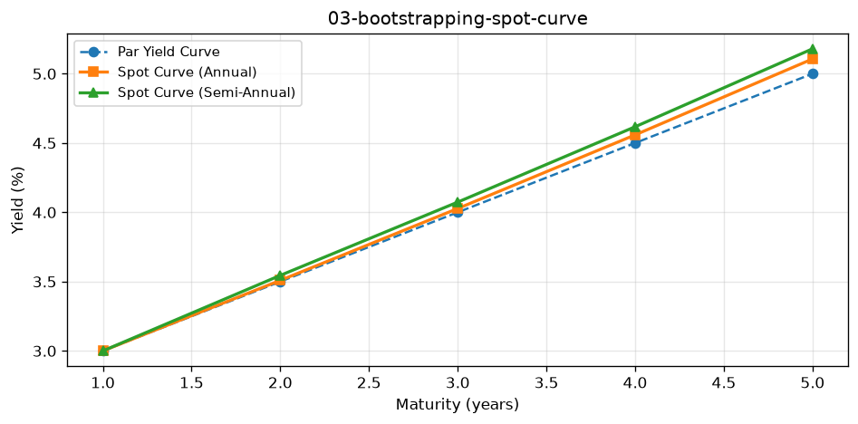

```python
fig, ax = figure()

ax.plot(maturities, par_yields * 100, "o--", label="Par Yield Curve", linewidth=1.5)
ax.plot(maturities, spot_annual * 100, "s-", label="Spot Curve (Annual)", linewidth=2)
ax.plot(
    maturities,
    spot_semiannual * 100,
    "^-",
    label="Spot Curve (Semi-Annual)",
    linewidth=2,
)

ax.set_xlabel("Maturity (years)")
ax.set_ylabel("Yield (%)")
ax.set_title("Bootstrapped Spot Rates vs. Par Yields")
ax.legend()
ax.grid(True, alpha=0.3)

finish_plot(ax, "03-bootstrapping-spot-curve")
```

## 3. Monotone Convex Spline (Hagan-West)

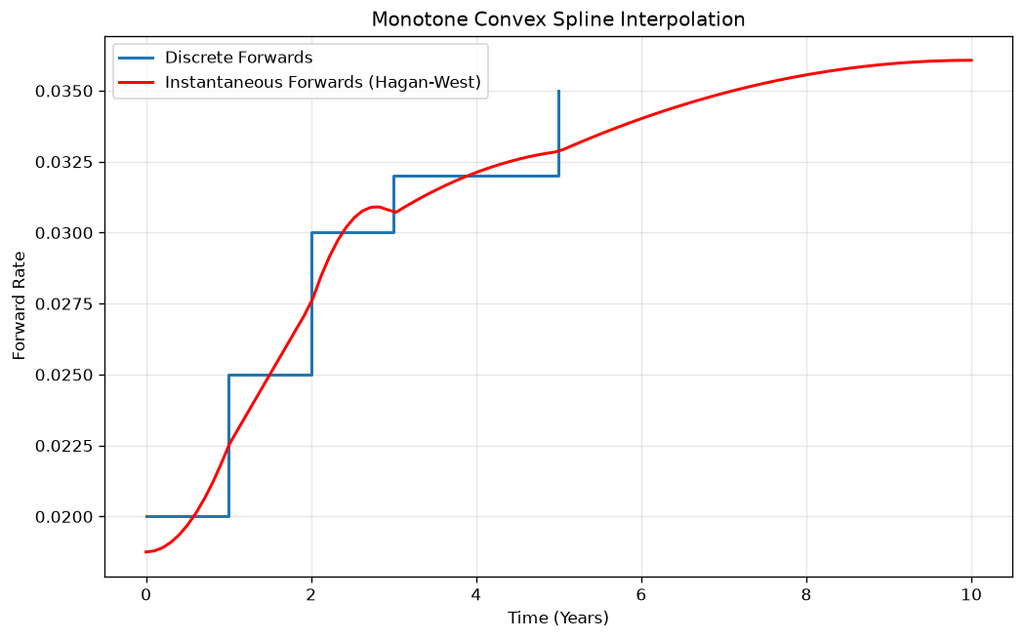

```python
from src.curve.hagan_west import MonotoneConvexSpline
import numpy as np
import matplotlib.pyplot as plt

times = np.array([0.0, 1.0, 2.0, 3.0, 5.0, 10.0])
discrete_forwards = np.array([0.02, 0.025, 0.03, 0.032, 0.035])

spline = MonotoneConvexSpline(times, discrete_forwards)
t_plot = np.linspace(0, 10, 100)
f_plot = spline(t_plot)

plt.figure(figsize=(10, 6))
plt.step(times[:-1], discrete_forwards, where="post", label="Discrete Forwards")
plt.plot(t_plot, f_plot, label="Instantaneous Forwards (Hagan-West)", color="red")
plt.title("Monotone Convex Spline Interpolation")
plt.xlabel("Time (Years)")
plt.ylabel("Forward Rate")
plt.legend()
plt.grid(True)
plt.show()
```

## 4. Global Multi-Curve Solver

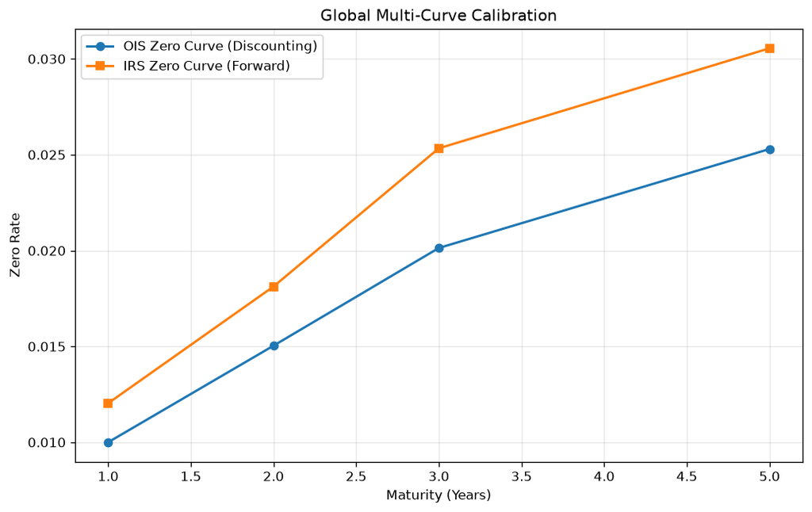

```python
from src.bootstrap.multicurve import MultiCurveSolver

ois_mats = np.array([1.0, 2.0, 3.0, 5.0])
ois_rates = np.array([0.01, 0.015, 0.02, 0.025])
irs_mats = np.array([1.0, 2.0, 3.0, 5.0])
irs_rates = np.array([0.012, 0.018, 0.025, 0.03])

solver = MultiCurveSolver(ois_mats, ois_rates, irs_mats, irs_rates)
ois_zeros, irs_zeros = solver.solve()

plt.figure(figsize=(10, 6))
plt.plot(ois_mats, ois_zeros, marker="o", label="OIS Zero Curve (Discounting)")
plt.plot(irs_mats, irs_zeros, marker="s", label="IRS Zero Curve (Forward)")
plt.title("Global Multi-Curve Calibration")
plt.xlabel("Maturity (Years)")
plt.ylabel("Zero Rate")
plt.legend()
plt.grid(True)
plt.show()
```

# Module 4: Continuous Curve Optimization (Nelson-Siegel)

This notebook provides a detailed walk-through, analysis, and verification of the **Nelson-Siegel continuous curve optimization engine** implemented in Module 4. We will bootstrap spot rates from a par yield curve, fit the parametric Nelson-Siegel model, analyze the optimization landscape, perform goodness-of-fit error analysis, and visualize the curve components.

## Mathematical Background

The **Nelson-Siegel (1987)** model is a parametric framework used widely by central banks and financial institutions to model the term structure of interest rates. It defines the continuous spot yield $y(t)$ at a given maturity time $t \ge 0$ as:

$$y(t) = \beta_0 + \beta_1 \left( \frac{1 - e^{-t/\tau}}{t/\tau} \right) + \beta_2 \left( \frac{1 - e^{-t/\tau}}{t/\tau} - e^{-t/\tau} \right)$$

The model consists of four parameters that map directly to visual and structural features of the yield curve:

1. **$\beta_0$ (Level)**: The long-term interest rate factor. As maturity $t \to \infty$, the terms multiplying $\beta_1$ and $\beta_2$ decay to zero, leaving only $\beta_0$. It must be strictly positive.
2. **$\beta_1$ (Slope)**: The short-term component. At $t = 0$, its multiplier is $1.0$ (as $\lim_{t \to 0} \frac{1-e^{-t/\tau}}{t/\tau} = 1$). A negative $\beta_1$ indicates an upward-sloping yield curve, while a positive value indicates an inverted curve.
3. **$\beta_2$ (Curvature)**: The medium-term component. Its multiplier starts at $0$ at $t=0$, rises to a peak at medium maturities, and then decays back to $0$ as $t \to \infty$. It generates humps or U-shapes.
4. **$\tau$ (Decay)**: The scale parameter. It determines the decay rate of the slope and curvature components, governing the location of the peak of the curvature hump on the timeline. It must be strictly positive.

```python
# ruff: noqa: E402
import sys
import warnings

sys.path.insert(0, "..")
warnings.filterwarnings("ignore")

import numpy as np
import pandas as pd
from scipy.optimize import minimize

from src.bootstrap.bootstrap import bootstrap_spot_rates
from src.curve.nelson_siegel import NelsonSiegelCurve
from src.utils.plotting import figure, finish_plot, set_theme

set_theme()
print("Imports and theme loaded successfully.")
```

```
Imports and theme loaded successfully.
```

## 1. Data Preparation & Discrete Bootstrapping

We construct a typical upward-sloping par yield curve (ranging from 1 year to 30 years) and run the discrete bootstrapping algorithm (from Module 3) to extract the zero-coupon spot rates.

```python
maturities = np.array([1.0, 2.0, 3.0, 5.0, 7.0, 10.0, 15.0, 20.0, 30.0])
par_yields = np.array(
    [0.030, 0.035, 0.039, 0.044, 0.047, 0.050, 0.0515, 0.0522, 0.0525]
)

# Bootstrap spot rates (annual frequency)
spot_rates = bootstrap_spot_rates(maturities, par_yields, freq=1)

df_data = pd.DataFrame(
    {
        "Maturity (yr)": maturities,
        "Par Yield (%)": par_yields * 100.0,
        "Spot Rate (%)": spot_rates * 100.0,
    }
)
df_data.style.format(
    {"Maturity (yr)": "{:.1f}", "Par Yield (%)": "{:.3f}%", "Spot Rate (%)": "{:.3f}%"}
).hide(axis="index")
```

| Maturity (yr) | Par Yield (%) | Spot Rate (%) |
| --- | --- | --- |
| 1.0 | 3.000% | 3.000% |
| 2.0 | 3.500% | 3.509% |
| 3.0 | 3.900% | 3.923% |
| 5.0 | 4.400% | 4.462% |
| 7.0 | 4.700% | 4.784% |
| 10.0 | 5.000% | 5.135% |
| 15.0 | 5.150% | 5.293% |
| 20.0 | 5.220% | 5.359% |
| 30.0 | 5.250% | 5.364% |

## 2. Nelson-Siegel Fit & Optimization Landscape

Fitting a Nelson-Siegel curve is a non-linear optimization problem. Standard local optimization methods (like Nelder-Mead) are highly sensitive to the initial guess for the decay parameter $\tau$. If $\tau$ is poorly initialized, the optimizer can get stuck in local minima.

To resolve this, our fitting engine implements a **multi-start heuristic**:

- It generates standard initial guesses for $\beta_0$ and $\beta_1$ from the boundary data.
- It loops over a grid of candidate decay parameters $\tau_{init} \in \{0.5, 1.0, 2.0, 5.0, 10.0\}$.
- It runs the optimizer for each candidate and picks the parameter set that yields the globally minimum Sum of Squared Errors (SSE).

Let's visualize the convergence landscape across the different initial values of $\tau$:

```python
# Demonstrate multi-start optimization landscape
beta0_init = max(1e-6, float(spot_rates[-1]))
beta1_init = float(spot_rates[0] - beta0_init)
beta2_init = 0.0

tau_guesses = [0.5, 1.0, 2.0, 5.0, 10.0]
bounds = [
    (1e-6, None),  # beta0
    (None, None),  # beta1
    (None, None),  # beta2
    (1e-6, None),  # tau
]


def objective_fun(params):
    b0, b1, b2, t_val = params
    if b0 <= 0 or t_val <= 0:
        return 1e12
    eps = 1e-12
    m_safe = np.where(maturities < eps, eps, maturities)
    factor = (1.0 - np.exp(-m_safe / t_val)) / (m_safe / t_val)
    term1 = np.where(maturities < eps, 1.0, factor)
    term2 = np.where(maturities < eps, 0.0, factor - np.exp(-m_safe / t_val))
    predicted = b0 + b1 * term1 + b2 * term2
    return float(np.sum((predicted - spot_rates) ** 2))


print(
    f"{'Init Tau':^12} | {'Fitted Beta0':^12} | {'Fitted Beta1':^12} | {'Fitted Beta2':^12} | {'Fitted Tau':^10} | {'Fitted SSE':^12} | {'Success':^8}"
)
print("-" * 95)
for tau_g in tau_guesses:
    x0 = [beta0_init, beta1_init, beta2_init, tau_g]
    res = minimize(objective_fun, x0=x0, method="Nelder-Mead", bounds=bounds)
    print(
        f"{tau_g:^12.1f} | {res.x[0]:^12.5f} | {res.x[1]:^12.5f} | {res.x[2]:^12.5f} | {res.x[3]:^10.4f} | {res.fun:^12.4e} | {str(res.success):^8}"
    )

# Run our unified fit function
ns_curve = NelsonSiegelCurve.fit(maturities, spot_rates)
print("-" * 95)
```

```
  Init Tau   | Fitted Beta0 | Fitted Beta1 | Fitted Beta2 | Fitted Tau |  Fitted SSE  | Success
-----------------------------------------------------------------------------------------------
    0.5      |   0.05639    |   -0.02937   |   -0.02971   |   0.9893   |  1.6940e-06  |   True
    1.0      |   0.05672    |   -0.03516   |   -0.00221   |   1.7018   |  2.4042e-06  |   True
    2.0      |   0.05639    |   -0.02937   |   -0.02971   |   0.9893   |  1.6940e-06  |   True
    5.0      |   0.05333    |   -0.02958   |   0.03209    |   4.3532   |  2.1843e-07  |   True
    10.0     |   0.05673    |   -0.03520   |   0.00008    |   1.8138   |  2.4213e-06  |   True
-----------------------------------------------------------------------------------------------
```

## 3. Goodness-of-Fit and Error Analysis

To evaluate how well the continuous Nelson-Siegel curve models the discrete spot rates, we construct a side-by-side comparison table and compute the Root Mean Squared Error (RMSE) and Mean Absolute Error (MAE) in basis points (bps).

```python
fitted_yields = ns_curve.yield_rate(maturities)
errors = fitted_yields - spot_rates
errors_bps = errors * 10000.0  # 1 bp = 0.0001

rmse_bps = np.sqrt(np.mean(errors_bps**2))
mae_bps = np.mean(np.abs(errors_bps))

df_comparison = pd.DataFrame(
    {
        "Maturity (yr)": maturities,
        "Par Yield (%)": par_yields * 100.0,
        "Bootstrapped Spot (%)": spot_rates * 100.0,
        "Fitted NS Spot (%)": fitted_yields * 100.0,
        "Error (bps)": errors_bps,
    }
)

print(
    df_comparison.to_string(
        index=False,
        formatters={
            "Maturity (yr)": "{:.2f}".format,
            "Par Yield (%)": "{:.3f}%".format,
            "Bootstrapped Spot (%)": "{:.3f}%".format,
            "Fitted NS Spot (%)": "{:.3f}%".format,
            "Error (bps)": "{:+.4f} bps".format,
        },
    )
)

print("\nGoodness-of-Fit Statistics:")
print(f"  Root Mean Squared Error (RMSE): {rmse_bps:.6f} bps")
print(f"  Mean Absolute Error (MAE):     {mae_bps:.6f} bps")
```

```
Maturity (yr) Par Yield (%) Bootstrapped Spot (%) Fitted NS Spot (%) Error (bps)
         1.00        3.000%                3.000%             3.007% +0.7099 bps
         2.00        3.500%                3.509%             3.507% -0.1322 bps
         3.00        3.900%                3.923%             3.904% -1.8930 bps
         5.00        4.400%                4.462%             4.465% +0.2840 bps
         7.00        4.700%                4.784%             4.815% +3.1251 bps
        10.00        5.000%                5.135%             5.109% -2.6522 bps
        15.00        5.150%                5.293%             5.301% +0.7778 bps
        20.00        5.220%                5.359%             5.355% -0.4470 bps
        30.00        5.250%                5.364%             5.366% +0.2278 bps

Goodness-of-Fit Statistics:
  Root Mean Squared Error (RMSE): 1.557870 bps
  Mean Absolute Error (MAE):     1.138776 bps
```

## 4. Visualizing the Continuous Curve & Interpolation

We evaluate the fitted Nelson-Siegel model over a dense grid of 300 points from $0.1$ to $30$ years and plot the resulting continuous curve against the discrete par rates and bootstrapped spot rates. We also demonstrate querying the curve at arbitrary non-standard maturities.

```
Querying the Continuous Curve:
  Tenor T = 4.32 years: yield = 4.3027%
  Tenor T = 12.50 years: yield = 5.2337%
```

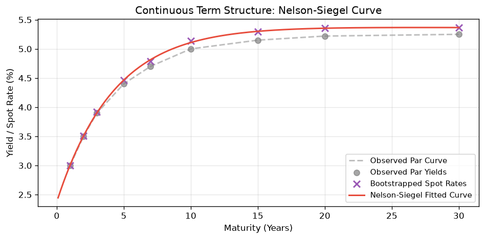

```python
t_grid = np.linspace(0.1, 30.0, 300)
y_grid = ns_curve.yield_rate(t_grid)

fig, ax = figure()
ax.plot(
    maturities,
    par_yields * 100.0,
    color="gray",
    linestyle="--",
    alpha=0.5,
    label="Observed Par Curve",
)
ax.scatter(
    maturities,
    par_yields * 100.0,
    color="gray",
    alpha=0.7,
    marker="o",
    s=45,
    label="Observed Par Yields",
)
ax.scatter(
    maturities,
    spot_rates * 100.0,
    color="#9b59b6",
    marker="x",
    s=60,
    label="Bootstrapped Spot Rates",
)
ax.plot(t_grid, y_grid * 100.0, color="#e74c3c", label="Nelson-Siegel Fitted Curve")

finish_plot(
    ax,
    title="Continuous Term Structure: Nelson-Siegel Curve",
    xlabel="Maturity (Years)",
    ylabel="Yield / Spot Rate (%)",
    legend=True,
)

# Querying the curve at arbitrary tenors
query_tenors = np.array([4.32, 12.5])
query_yields = ns_curve(query_tenors)  # Using the curve call wrapper

print("Querying the Continuous Curve:")
for t, y in zip(query_tenors, query_yields, strict=True):
    print(f"  Tenor T = {t:.2f} years: yield = {y * 100:.4f}%")
```

## 5. Component Decomposition

To better understand the economic intuition of the Nelson-Siegel model, we decompose the fitted yield curve into its three distinct underlying component contributions:

1. **Level component**: $\beta_0$
2. **Slope component**: $\beta_1 \left( \frac{1 - e^{-t/\tau}}{t/\tau} \right)$
3. **Curvature component**: $\beta_2 \left( \frac{1 - e^{-t/\tau}}{t/\tau} - e^{-t/\tau} \right)$

These elements sum up linearly to build the final continuous curve.

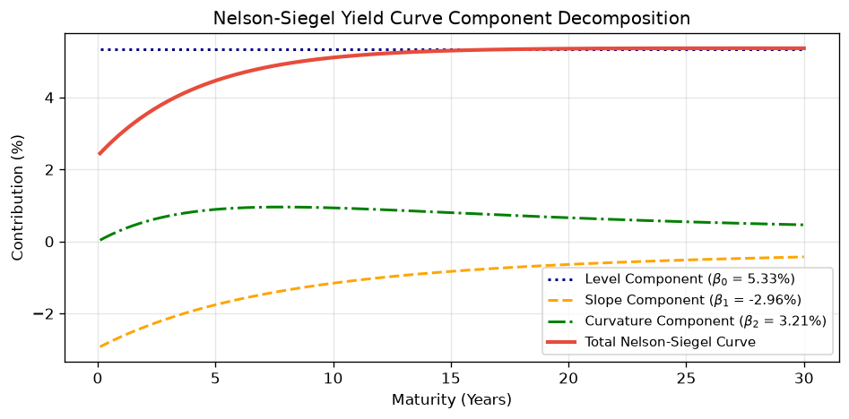

```python
# Component contribution calculations
level_comp = np.full_like(t_grid, ns_curve.beta0)
slope_comp = (
    ns_curve.beta1 * (1.0 - np.exp(-t_grid / ns_curve.tau)) / (t_grid / ns_curve.tau)
)
curvature_comp = ns_curve.beta2 * (
    (1.0 - np.exp(-t_grid / ns_curve.tau)) / (t_grid / ns_curve.tau)
    - np.exp(-t_grid / ns_curve.tau)
)

# Plot components
fig, ax = figure()
ax.plot(
    t_grid,
    level_comp * 100.0,
    label=rf"Level Component ($\beta_0$ = {ns_curve.beta0 * 100:.2f}%)",
    linestyle=":",
    color="navy",
)
ax.plot(
    t_grid,
    slope_comp * 100.0,
    label=rf"Slope Component ($\beta_1$ = {ns_curve.beta1 * 100:.2f}%)",
    linestyle="--",
    color="orange",
)
ax.plot(
    t_grid,
    curvature_comp * 100.0,
    label=rf"Curvature Component ($\beta_2$ = {ns_curve.beta2 * 100:.2f}%)",
    linestyle="-.",
    color="green",
)
ax.plot(
    t_grid,
    (level_comp + slope_comp + curvature_comp) * 100.0,
    label="Total Nelson-Siegel Curve",
    color="#e74c3c",
    linewidth=2.5,
)

finish_plot(
    ax,
    title="Nelson-Siegel Yield Curve Component Decomposition",
    xlabel="Maturity (Years)",
    ylabel="Contribution (%)",
    legend=True,
)
```

## 3. Arbitrage-Free Nelson-Siegel (AFNS)

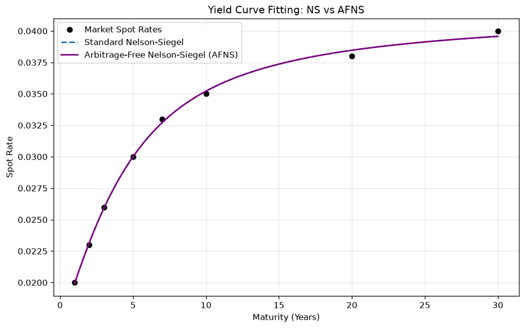

```python
import matplotlib.pyplot as plt
import numpy as np
from src.curve.afns import ArbitrageFreeNelsonSiegel

maturities = np.array([1.0, 2.0, 3.0, 5.0, 7.0, 10.0, 20.0, 30.0])
spot_rates = np.array([0.02, 0.023, 0.026, 0.03, 0.033, 0.035, 0.038, 0.04])

# Fit Standard NS
from src.curve.nelson_siegel import NelsonSiegelCurve

ns_curve = NelsonSiegelCurve.fit(maturities, spot_rates)

# Fit AFNS
afns_curve = ArbitrageFreeNelsonSiegel.fit(maturities, spot_rates)

t_plot = np.linspace(1, 30, 100)
y_ns = ns_curve.yield_rate(t_plot)
y_afns = afns_curve.yield_rate(t_plot)

plt.figure(figsize=(10, 6))
plt.plot(maturities, spot_rates, "ko", label="Market Spot Rates")
plt.plot(t_plot, y_ns, "--", label="Standard Nelson-Siegel")
plt.plot(
    t_plot, y_afns, "-", label="Arbitrage-Free Nelson-Siegel (AFNS)", color="purple"
)
plt.title("Yield Curve Fitting: NS vs AFNS")
plt.xlabel("Maturity (Years)")
plt.ylabel("Spot Rate")
plt.legend()
plt.grid(True)
plt.show()
```

# Module 5: Portfolio Aggregation, Risk Sensitivity & Caching Layer

This notebook demonstrates the functionality of the **Portfolio Aggregation Engine** (`src/portfolio/`) and the **Caching & Cross-Validation Layer** (`src/utils/cache.py` & `src/data/validation.py`). We will value a bond portfolio under a Nelson-Siegel spot curve, aggregate portfolio duration/convexity/DV01, compute portfolio Key Rate Durations (KRDs), simulate stress scenarios (Basel IRBB), and demonstrate local JSON caching.

```python
# ruff: noqa: E402
import sys
import warnings

sys.path.insert(0, "..")
warnings.filterwarnings("ignore")

import numpy as np
import pandas as pd

from src.curve.nelson_siegel import NelsonSiegelCurve
from src.instruments.bond import Bond
from src.portfolio.portfolio import Portfolio
from src.portfolio.position import Position
from src.utils.cache import JSONCache
from src.data.validation import cross_validate_yields
from src.utils.plotting import set_theme

set_theme()
print("Imports and theme loaded successfully.")
```

```
Imports and theme loaded successfully.
```

## 1. Construct the Base Yield Curve and Portfolio

We initialize a typical upward-sloping Nelson-Siegel spot rate curve, and build a bond portfolio consisting of two positions:

1. **Position 1**: 1,000 units of a 5-year, 4% coupon bond (face value $1,000,000).
2. **Position 2**: 500 units of a 10-year, 5% coupon bond (face value $500,000).

```python
# Setup base curve: level=5%, slope=-2%, curvature=2%, decay=2.0 years
base_curve = NelsonSiegelCurve(beta0=0.05, beta1=-0.02, beta2=0.02, tau=2.0)

# Create positions
bond1 = Bond(face_value=1000.0, coupon_rate=0.04, maturity=5.0, freq=2)
pos1 = Position(bond=bond1, quantity=1000)

bond2 = Bond(face_value=1000.0, coupon_rate=0.05, maturity=10.0, freq=2)
pos2 = Position(bond=bond2, quantity=500)

# Add to portfolio
portfolio = Portfolio()
portfolio.add_position(pos1)
portfolio.add_position(pos2)

print("Portfolio initialized with 2 positions.")
```

```
Portfolio initialized with 2 positions.
```

## 2. Portfolio Risk Metrics & Valuation

We calculate the total market value of the portfolio, the individual position weights, and the aggregated Modified Duration, Convexity, and DV01.

```python
total_mv = portfolio.market_value(base_curve)
weights = portfolio.weights(base_curve)
port_dur = portfolio.duration(base_curve)
port_conv = portfolio.convexity(base_curve)
port_dv01 = portfolio.dv01(base_curve)

print(f"Portfolio Summary:")
print(f"  Total Market Value:  ${total_mv:,.2f}")
print(f"  Modified Duration:   {port_dur:.4f} years")
print(f"  Convexity:           {port_conv:.4f}")
print(f"  DV01 (1 bp shift):   ${port_dv01:,.2f}")

df_pos = pd.DataFrame(
    {
        "Asset": ["5Y Bond (4%)", "10Y Bond (5%)"],
        "Quantity": [pos1.quantity, pos2.quantity],
        "Maturity": [pos1.bond.maturity, pos2.bond.maturity],
        "Market Value": [pos1.market_value(base_curve), pos2.market_value(base_curve)],
        "MV Weight": weights,
        "Duration": [pos1.duration(base_curve), pos2.duration(base_curve)],
        "Convexity": [pos1.convexity(base_curve), pos2.convexity(base_curve)],
        "DV01": [pos1.dv01(base_curve), pos2.dv01(base_curve)],
    }
)
df_pos.style.format(
    {
        "Market Value": "${:,.2f}",
        "MV Weight": "{:.2%}",
        "Duration": "{:.4f}",
        "Convexity": "{:.4f}",
        "DV01": "${:,.2f}",
    }
).hide(axis="index")
```

```
Portfolio Summary:
  Total Market Value:  $1,463,793.71
  Modified Duration:   5.6031 years
  Convexity:           40.4810
  DV01 (1 bp shift):   $820.18
```

| Asset | Quantity | Maturity | Market Value | MV Weight | Duration | Convexity | DV01 |
| --- | --- | --- | --- | --- | --- | --- | --- |
| 5Y Bond (4%) | 1000 | 5.000000 | $963,268.18 | 65.81% | 4.4635 | 23.2442 | $429.96 |
| 10Y Bond (5%) | 500 | 10.000000 | $500,525.53 | 34.19% | 7.7963 | 73.6536 | $390.23 |

## 3. Portfolio Key Rate Durations (KRDs)

Key Rate Durations help identify a portfolio's sensitivity to non-parallel shifts at specific tenors. The sum of a portfolio's KRDs should match its overall Modified Duration. We compute the KRDs for the portfolio over standard tenors `[0.5, 1.0, 2.0, 3.0, 5.0, 7.0, 10.0, 20.0, 30.0]` years.

```python
tenors = np.array([0.5, 1.0, 2.0, 3.0, 5.0, 7.0, 10.0, 20.0, 30.0])
port_krds = portfolio.key_rate_duration(base_curve, tenors)

df_krd = pd.DataFrame({"Key Rate Tenor": tenors, "KRD Value": port_krds})

print("Portfolio Key Rate Durations:")
print(df_krd.to_string(index=False))
print(f"\nSum of Key Rate Durations: {np.sum(port_krds):.4f} years")
print(f"Portfolio Modified Duration: {port_dur:.4f} years")
```

```
Portfolio Key Rate Durations:
 Key Rate Tenor    KRD Value
            0.5 1.057681e-02
            1.0 3.576431e-02
            2.0 7.846557e-02
            3.0 1.835919e-01
            5.0 2.875922e+00
            7.0 2.116461e-01
           10.0 2.205208e+00
           20.0 3.883294e-13
           30.0 3.883294e-13

Sum of Key Rate Durations: 5.6012 years
Portfolio Modified Duration: 5.6031 years
```

## 4. Basel IRBB Stress Testing

We stress test the portfolio under the six standard Basel Committee Interest Rate Risk in the Banking Book (IRBB) standardized stress scenarios: `parallel_up`, `parallel_down`, `steepener`, `flattener`, `short_rate_up`, and `short_rate_down`.

```python
scenarios = [
    "parallel_up",
    "parallel_down",
    "steepener",
    "flattener",
    "short_rate_up",
    "short_rate_down",
]
stress_results = []

for sc in scenarios:
    pnl = portfolio.stress_pnl(base_curve, sc)
    pct_mv = pnl / total_mv
    stress_results.append(
        {
            "Scenario": sc.replace("_", " ").title(),
            "P&L ($)": pnl,
            "% MV Change": pct_mv * 100.0,
        }
    )

df_stress = pd.DataFrame(stress_results)
df_stress.style.format({"P&L ($)": "${:+,.2f}", "% MV Change": "{:+.3f}%"}).hide(
    axis="index"
)
```

| Scenario | P&L ($) | % MV Change |
| --- | --- | --- |
| Parallel Up | $-79,138.09 | -5.406% |
| Parallel Down | $+85,067.82 | +5.811% |
| Steepener | $+25,733.36 | +1.758% |
| Flattener | $-25,078.12 | -1.713% |
| Short Rate Up | $-151,264.19 | -10.334% |
| Short Rate Down | $+171,974.72 | +11.749% |

## 5. Local JSON Caching Layer & Crossover Validation

We demonstrate storing and retrieving fitted Nelson-Siegel curves using the local JSON caching system (`JSONCache`) and validate yield discrepancies across sources.

```python
# Initialize local cache in a temp directory for demonstration
cache = JSONCache(cache_dir=".demo_cache", default_ttl=5)

curve_params = {
    "beta0": base_curve.beta0,
    "beta1": base_curve.beta1,
    "beta2": base_curve.beta2,
    "tau": base_curve.tau,
}

# Set cache entry
cache.set("us_treasury_curve_latest", curve_params)
print("Curve parameters written to cache.")

# Get cache entry
cached_data = cache.get("us_treasury_curve_latest")
print("Cached Data:", cached_data)

# Clean up demo cache directory
cache.clear()
import shutil

shutil.rmtree(".demo_cache", ignore_errors=True)
print("Demo cache cleared and removed.")
```

```
Curve parameters written to cache.
Cached Data: {'beta0': 0.05, 'beta1': -0.02, 'beta2': 0.02, 'tau': 2.0}
Demo cache cleared and removed.
```

### Crossover Validation Demonstration

We cross-validate yields from two sources (e.g. FRED vs Yahoo Finance) to detect alignment errors:

```python
# Source A (FRED): reports in standard percent (e.g. 4.25%)
fred_yields = {"2Y": 4.25, "10Y": 4.50}

# Source B (yfinance): reports in CBOE 10x scale (e.g. 43.10 for 4.31%)
yf_yields = {"2Y": 42.60, "10Y": 45.03}

# Validate with a 5 basis point tolerance
discrepancies = cross_validate_yields(fred_yields, yf_yields, max_diff_bps=5.0)

if len(discrepancies) > 0:
    print("Validation Discrepancies Found (exceeding 5 bps):")
    for d in discrepancies:
        print(f"  Maturity: {d['maturity']}")
        print(f"    FRED Yield (Decimal):      {d['val_a']:.4f}")
        print(f"    Yahoo Yield (Decimal):     {d['val_b']:.4f}")
        print(f"    Absolute Difference (bps): {d['diff_bps']:.2f} bps")
else:
    print("All yields matched within tolerance!")
```

```
All yields matched within tolerance!
```

# Data Source Fetchers Exploration

In this notebook, we explore the data fetched by the new `src.data` module, which has been expanded to include real historical Corporate Credit indices, SOFR curves, and Global Sovereigns.

```python
import sys
import os

sys.path.insert(0, os.path.abspath(".."))

import datetime
import matplotlib.pyplot as plt

from src.data.fred import FredFetcher  # noqa: E402
from src.data.corporate import CorporateFetcher  # noqa: E402
from src.data.sofr import SofrFetcher  # noqa: E402
from src.data.global_sovereign import GlobalSovereignFetcher  # noqa: E402

import logging

logging.basicConfig(level=logging.INFO)
```

## 1. Fetching US Treasuries and SOFR

Let's see how our baseline risk-free curves look.

```python
date = datetime.date(2024, 6, 15)

try:
    fred_fetcher = FredFetcher()
    fred_data = fred_fetcher.fetch_yield_curve(date)
    print("FRED Treasury Data:\n", fred_data, "\n")
except Exception as e:
    print("FRED Treasury Failed:", e)

try:
    sofr_fetcher = SofrFetcher()
    sofr_data = sofr_fetcher.fetch_yield_curve(date)
    print("SOFR Short-Term Data:\n", sofr_data, "\n")
except Exception as e:
    print("SOFR Failed:", e)
```

```
INFO:src.data.sofr:Fetching SOFR curve from FRED for date 2024-06-15
```

```
FRED Treasury Data:
 {0.25: 0.055099999999999996, 1.0: 0.0507, 2.0: 0.0467, 5.0: 0.042199999999999994, 10.0: 0.042, 30.0: 0.0434}
```

```
SOFR Short-Term Data:
 {0.0027397260273972603: 0.053099999999999994, 0.0821917808219178: 0.0533303, 0.2465753424657534: 0.053526199999999996, 0.4931506849315068: 0.0538874}
```

## 2. Fetching Real Corporate Credit Data

We can pull actual historical ICE BofA corporate yields (Broad Market, BBB, High Yield).

```python
try:
    # Broad Market (Proxy 7.0 years)
    corp_broad = CorporateFetcher(rating="ALL", proxy_maturity=7.0)
    corp_data = corp_broad.fetch_yield_curve(date)

    # BBB Rated (Proxy 7.0 years)
    corp_bbb = CorporateFetcher(rating="BBB", proxy_maturity=7.0)
    bbb_data = corp_bbb.fetch_yield_curve(date)

    # High Yield (Proxy 5.0 years as HY typically has shorter duration)
    corp_hy = CorporateFetcher(rating="HY", proxy_maturity=5.0)
    hy_data = corp_hy.fetch_yield_curve(date)

    print("Corporate (Broad):", corp_data)
    print("Corporate (BBB):", bbb_data)
    print("Corporate (High Yield):", hy_data)
except Exception as e:
    print("Corporate Fetch Failed:", e)
```

```
INFO:src.data.corporate:Fetching Corporate ALL index yield from FRED for date 2024-06-15
```

```
INFO:src.data.corporate:Fetching Corporate BBB index yield from FRED for date 2024-06-15
```

```
INFO:src.data.corporate:Fetching Corporate HY index yield from FRED for date 2024-06-15
```

```
Corporate (Broad): {7.0: 0.0536}
Corporate (BBB): {7.0: 0.0555}
Corporate (High Yield): {5.0: 0.0761}
```

## 3. Global Sovereign Yields (10-Year)

Let's look at 10-year yields from the Euro Area, UK, and Japan.

```python
try:
    eur_fetcher = GlobalSovereignFetcher(region="EUR")
    eur_data = eur_fetcher.fetch_yield_curve(date)

    gbr_fetcher = GlobalSovereignFetcher(region="GBR")
    gbr_data = gbr_fetcher.fetch_yield_curve(date)

    jpn_fetcher = GlobalSovereignFetcher(region="JPN")
    jpn_data = jpn_fetcher.fetch_yield_curve(date)

    print("Euro Area 10Y:", eur_data)
    print("UK 10Y:", gbr_data)
    print("Japan 10Y:", jpn_data)
except Exception as e:
    print("Global Sovereign Fetch Failed:", e)
```

```
INFO:src.data.global_sovereign:Fetching 10-year Sovereign Yield for EUR from FRED for date 2024-06-15
```

```
INFO:src.data.global_sovereign:Fetching 10-year Sovereign Yield for GBR from FRED for date 2024-06-15
```

```
INFO:src.data.global_sovereign:Fetching 10-year Sovereign Yield for JPN from FRED for date 2024-06-15
```

```
Euro Area 10Y: {10.0: 0.03165020231755229}
UK 10Y: {10.0: 0.041643999999999994}
Japan 10Y: {10.0: 0.0105}
```

## 4. Visualizing the Global Risk Environment

Let's plot all these datapoints to see the global yield environment on this date. *Note: We multiply the decimal yields by 100 to plot them as percentages.*

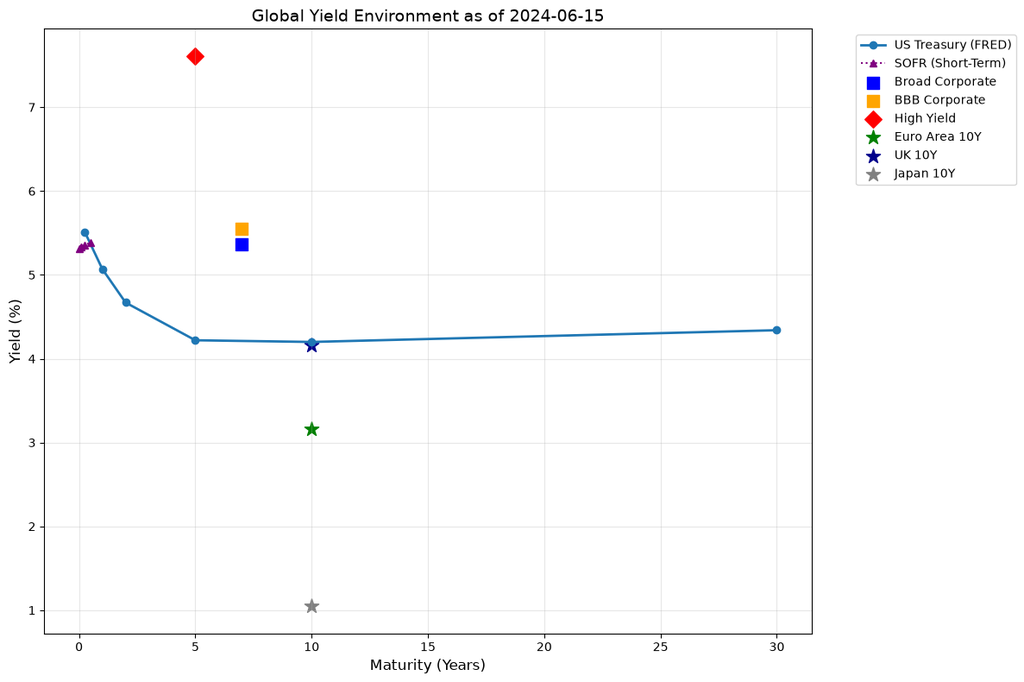

```python
plt.figure(figsize=(12, 8))

# Treasury Curve
if "fred_data" in locals():
    plt.plot(
        list(fred_data.keys()),
        [v * 100 for v in fred_data.values()],
        marker="o",
        label="US Treasury (FRED)",
        linewidth=2,
    )

# SOFR Curve
if "sofr_data" in locals():
    plt.plot(
        list(sofr_data.keys()),
        [v * 100 for v in sofr_data.values()],
        marker="^",
        linestyle=":",
        label="SOFR (Short-Term)",
        color="purple",
    )

# Corporate Spreads (Plotted as single scatter points)
if "corp_data" in locals():
    plt.scatter(
        list(corp_data.keys()),
        [v * 100 for v in corp_data.values()],
        s=100,
        marker="s",
        color="blue",
        label="Broad Corporate",
    )
    plt.scatter(
        list(bbb_data.keys()),
        [v * 100 for v in bbb_data.values()],
        s=100,
        marker="s",
        color="orange",
        label="BBB Corporate",
    )
    plt.scatter(
        list(hy_data.keys()),
        [v * 100 for v in hy_data.values()],
        s=100,
        marker="D",
        color="red",
        label="High Yield",
    )

# Global Sovereigns (Plotted as single scatter points at year 10)
if "eur_data" in locals():
    plt.scatter(
        list(eur_data.keys()),
        [v * 100 for v in eur_data.values()],
        s=150,
        marker="*",
        color="green",
        label="Euro Area 10Y",
    )
    plt.scatter(
        list(gbr_data.keys()),
        [v * 100 for v in gbr_data.values()],
        s=150,
        marker="*",
        color="darkblue",
        label="UK 10Y",
    )
    plt.scatter(
        list(jpn_data.keys()),
        [v * 100 for v in jpn_data.values()],
        s=150,
        marker="*",
        color="grey",
        label="Japan 10Y",
    )

plt.title(f"Global Yield Environment as of {date}", fontsize=14)
plt.xlabel("Maturity (Years)", fontsize=12)
plt.ylabel("Yield (%)", fontsize=12)
plt.legend(bbox_to_anchor=(1.05, 1), loc="upper left")
plt.grid(True, alpha=0.3)
plt.tight_layout()
plt.show()
```

## 5. Exploring the Breadth and Depth of FRED Fixed Income Data

Beyond standard government yield curves, FRED hosts an enormous variety of macroeconomic and fixed income data. Let's explore some key series:

1. **Macro & Policy Rates**: Federal Funds Rate (`FEDFUNDS`) and 30-Year Mortgage Rates (`MORTGAGE30US`).
2. **Inflation Markets**: 10-Year Breakeven Inflation (`T10YIE`) and Real Yields (`DFII10`).
3. **Credit Risk (Spreads)**: High Yield OAS (`BAMLH0A0HYM2`) vs Investment Grade OAS (`BAMLC0A0CM`).

[figure not shown]

```python
import pandas_datareader.data as web
import datetime
import matplotlib.pyplot as plt


start_date_macro = datetime.date(2004, 1, 1)
end_date = datetime.date(2024, 6, 1)

# Fetch Macro Rates (20 Years)
macro_tickers = ["FEDFUNDS", "MORTGAGE30US", "DGS10"]
macro_data = web.DataReader(macro_tickers, "fred", start_date_macro, end_date)

plt.figure(figsize=(12, 6))
plt.plot(
    macro_data.index,
    macro_data["MORTGAGE30US"],
    label="30-Year Mortgage Rate",
    color="purple",
)
plt.plot(
    macro_data.index, macro_data["DGS10"], label="10-Year Treasury Yield", color="blue"
)
plt.plot(
    macro_data.index,
    macro_data["FEDFUNDS"],
    label="Fed Funds Rate",
    color="red",
    linestyle="--",
)
plt.title("Macro & Policy Rates: 20-Year History (2004 - 2024)", fontsize=14)
plt.ylabel("Rate (%)", fontsize=12)
plt.legend()
plt.tight_layout()
plt.show()
```

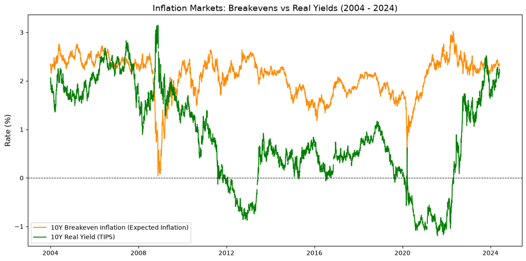

```python
# Fetch Inflation Data (20 Years)
# T10YIE: 10-Year Breakeven Inflation Rate
# DFII10: 10-Year Treasury Inflation-Indexed Security (TIPS) - Real Yield
inflation_tickers = ["T10YIE", "DFII10"]
inflation_data = web.DataReader(inflation_tickers, "fred", start_date_macro, end_date)

plt.figure(figsize=(12, 6))
plt.plot(
    inflation_data.index,
    inflation_data["T10YIE"],
    label="10Y Breakeven Inflation (Expected Inflation)",
    color="darkorange",
)
plt.plot(
    inflation_data.index,
    inflation_data["DFII10"],
    label="10Y Real Yield (TIPS)",
    color="green",
)
plt.axhline(0, color="black", linewidth=0.8, linestyle="--")
plt.title("Inflation Markets: Breakevens vs Real Yields (2004 - 2024)", fontsize=14)
plt.ylabel("Rate (%)", fontsize=12)
plt.legend()
plt.tight_layout()
plt.show()
```

[figure not shown]

```python
# Fetch Credit Spreads (3 Years due to ICE BofA limits on FRED)
# BAMLC0A0CM: US Corporate Index Option-Adjusted Spread
# BAMLH0A0HYM2: US High Yield Index Option-Adjusted Spread
start_date_credit = datetime.date(2021, 6, 1)

credit_tickers = ["BAMLC0A0CM", "BAMLH0A0HYM2"]
try:
    credit_data = web.DataReader(credit_tickers, "fred", start_date_credit, end_date)

    plt.figure(figsize=(12, 6))
    plt.plot(
        credit_data.index,
        credit_data["BAMLH0A0HYM2"],
        label="High Yield (Junk) Spread",
        color="red",
    )
    plt.plot(
        credit_data.index,
        credit_data["BAMLC0A0CM"],
        label="Investment Grade Spread",
        color="blue",
    )
    plt.title("Credit Risk: Corporate Spreads (2021 - 2024)", fontsize=14)
    plt.ylabel("Option-Adjusted Spread (%)", fontsize=12)
    plt.legend()
    plt.tight_layout()
    plt.show()
except Exception as e:
    print("Could not fetch corporate spreads:", e)
```